# MATH1062 Statistics: Week 1 - Getting Started with R

Author

School of Mathematics and Statistics, University of Sydney

# Welcome! 🤗 ✌🏼

This is an introduction to **R**, **RStudio** and **Quarto** documents for MATH1062.

In this guide, we will introduce you to the **very basics of R programming** to get you started in your coding journey in MATH1062! This document assumes you have none to very little programming experience. Feel free to go over this quickly if you’re already familiar with R, and equally, feel free to seek help from the lecturer or tutors if you need help with any of these exercises and examples.

More specifically, this Quarto document will cover:

- How to run R code
- How to “render” a Quarto document to produce an HTML file (you’ll need to do this for the assignments).
- What variables are and the main types of data in R
- How to read in a CSV file (including common mistakes and how to fix them)
- How to select columns and rows in a data frame
- How to make basic plots
- Doing all of the above in **base R** first, then with the **tidyverse** library/package.

## Getting to know RStudio

When you open RStudio, you’ll usually see **four main panes (windows)**:

1. **Source / Editor (top-left)**
   - Where you write your R scripts or Quarto documents.
   - You can have multiple tabs open for different files.
2. **Console (bottom-left)**
   - This is where R actually runs commands.
   - You can type code directly here to try something out, or send code from the Source pane to run.
   - When you run a Quarto document, this is where the code executes.
3. **Environment / History (top-right)**
   - **Environment tab**: Shows all the variables, data frames, and functions you’ve created in your current R session.
   - **History tab**: A record of all the commands you’ve run.
4. **Files / Plots / Help / Packages (bottom-right)**
   - **Files**: Browse files and folders on your computer.
   - **Help**: View documentation for functions and packages.
   - **Packages**: See which R packages are installed and to install new packages.

💡 **Tip:** If your RStudio layout looks different, you can reset it via  
**Tools → Global Options → Pane Layout**.

# Running R code

Before we start running R code, let’s learn how to **add code chunks** to a Quarto document.

In RStudio, you can insert a new R code chunk in several ways:

- **Mac**: Press `Command` + `Option` + `I`
- **Windows**: Press `Ctrl` + `Alt` + `I`
- Or click the **Code** at the top of the RStudio window and choose **Insert Chunk**.

A new chunk will look like this:

```r
# If a line in a code chunk begins with #, the line will appear green and is treated as a comment, not R code to be run.
```

Once you have a code chunk, you can run the code inside it using:

- **Mac**: Highlight the code (or place your cursor in the line) and press `Command` + `Return`
- **Windows**: Highlight the code (or place your cursor in the line) and press `Ctrl` + `Enter`
- Or click the **little green arrow** ▶️ at the top-right of a code chunk.

In Quarto documents, you put your R code inside code chunks like this:

```r
1 + 1
```

```
[1] 2
```

When you run this chunk, R will add **1 and 1** together and show the result.

## Rendering your Quarto document

Once you’ve written your text and code in a Quarto (`.qmd`) file, you need to **render** it so it produces the final output (for example, an HTML file you can view in your browser).

In RStudio, there are two main ways to render:

1. **Click the Render button** at the top of the RStudio editor
   - It’s a blue button with “Render” written on it.
2. **Use a keyboard shortcut**:
   - **Mac**: `Command` + `Shift` + `K`
   - **Windows**: `Ctrl` + `Shift` + `K`

When you render: - Quarto runs all your R code chunks in order. - It produces a document (usually `.html`) with your text and the results of your code. - You’ll see the rendered document appear in the Viewer pane or your web browser.

💡 **Tip:** If you make changes to your code or text, you need to render again to see them reflected in the output.

# Part 1: Base R

## Variables

Think of a variable as a **named box** where you store information.  
We use `<-` to put something into a variable:

```r
my_number <- 42
my_text <- "Hello, R!"
```

- `my_number` now stores the number 42.
- `my_text` now stores the text `"Hello, R!"`.

To see what’s inside:

```r
my_number
```

```
[1] 42
```

## Types of variables

R works with different **data types**:

| Type | Example | Description |
| --- | --- | --- |
| Numeric | `3.14` | Numbers you can calculate with |
| Integer | `42L` | Whole numbers |
| Character | `"Hello"` | Text |
| Logical/Boolean | `TRUE`, `FALSE` | True/false values |
| Factor | `factor(c("Red", "Blue"))` | Categories |

### Exercise 1

1. Create a variable called `age` with your age.
2. Create a variable called `name` with your first name.
3. Print them both.

```r
age <- 18
name <- 'Kierin'
name
```

```
[1] "Kierin"
```

```r
age
```

```
[1] 18
```

## Reading in a CSV file

Most of the data we will deal with in this unit comes in a `.csv` file (Comma-Separated Values).  
To read it into R, use:

```r
# We've commented out this line now, so that the Quarto document renders into an html document without errors.

#my_data <- read.csv("myfile.csv")
```

- `"myfile.csv"` is the name of the file you want to read.
- `my_data` will be a **data frame** (think: a table of data or something like an Excel spreadsheet or Google sheet).

**Common problems and how to fix them:**

1. **File not found error** – This means R can’t see your file.
   - Make sure the file is in your **working directory** (which is where **R** is currently looking for files) Use `getwd()` to check, `setwd()` to change.
   - Often it is easiest to use the full file path like `"C:/Users/YourName/Documents/myfile.csv"` on Windows or `"/Users/YourName/Documents/myfile.csv"` on Mac.
2. **Wrong slashes on Windows** – Use forward slashes `/` not backslashes `\` in paths.
3. **File in Downloads folder** – Move it to a simpler folder like `Documents`.

To look at the first few rows of the data, use the `head()` function:

```r
# We've commented out this line now, so that the Quarto document renders into an html document without errors.

#head(my_data)
```

The `str()` function gives you basic information about a data frame, like how many rows and variables it has, and the data types of these variables:

```r
# We've commented out this line now, so that the Quarto document renders into an html document without errors.

#str(my_data)
```

For now, we’ll use a built-in dataset: `mtcars`.

```r
head(mtcars)
```

```
                   mpg cyl disp  hp drat    wt  qsec vs am gear carb
Mazda RX4         21.0   6  160 110 3.90 2.620 16.46  0  1    4    4
Mazda RX4 Wag     21.0   6  160 110 3.90 2.875 17.02  0  1    4    4
Datsun 710        22.8   4  108  93 3.85 2.320 18.61  1  1    4    1
Hornet 4 Drive    21.4   6  258 110 3.08 3.215 19.44  1  0    3    1
Hornet Sportabout 18.7   8  360 175 3.15 3.440 17.02  0  0    3    2
Valiant           18.1   6  225 105 2.76 3.460 20.22  1  0    3    1
```

```r
str(mtcars)
```

```
'data.frame':   32 obs. of  11 variables:
 $ mpg : num  21 21 22.8 21.4 18.7 18.1 14.3 24.4 22.8 19.2 ...
 $ cyl : num  6 6 4 6 8 6 8 4 4 6 ...
 $ disp: num  160 160 108 258 360 ...
 $ hp  : num  110 110 93 110 175 105 245 62 95 123 ...
 $ drat: num  3.9 3.9 3.85 3.08 3.15 2.76 3.21 3.69 3.92 3.92 ...
 $ wt  : num  2.62 2.88 2.32 3.21 3.44 ...
 $ qsec: num  16.5 17 18.6 19.4 17 ...
 $ vs  : num  0 0 1 1 0 1 0 1 1 1 ...
 $ am  : num  1 1 1 0 0 0 0 0 0 0 ...
 $ gear: num  4 4 4 3 3 3 3 4 4 4 ...
 $ carb: num  4 4 1 1 2 1 4 2 2 4 ...
```

## Selecting columns

To select a column:

```r
mtcars$mpg
```

```
 [1] 21.0 21.0 22.8 21.4 18.7 18.1 14.3 24.4 22.8 19.2 17.8 16.4 17.3 15.2 10.4
[16] 10.4 14.7 32.4 30.4 33.9 21.5 15.5 15.2 13.3 19.2 27.3 26.0 30.4 15.8 19.7
[31] 15.0 21.4
```

This gives the **mpg** (miles per gallon) column.

Another way:

```r
mtcars[ , "mpg"]
```

```
 [1] 21.0 21.0 22.8 21.4 18.7 18.1 14.3 24.4 22.8 19.2 17.8 16.4 17.3 15.2 10.4
[16] 10.4 14.7 32.4 30.4 33.9 21.5 15.5 15.2 13.3 19.2 27.3 26.0 30.4 15.8 19.7
[31] 15.0 21.4
```

**General syntax:**

```
dataframe[rows, columns]
```

Leaving `rows` blank means “all rows”.

### Selecting multiple columns

In **base R**, you can select **more than one column** by putting a *vector* of column names or numbers inside the column part of the square brackets.

#### 1. By column names (recommended)

```r
mtcars[ , c("mpg", "hp")]
```

```
                     mpg  hp
Mazda RX4           21.0 110
Mazda RX4 Wag       21.0 110
Datsun 710          22.8  93
Hornet 4 Drive      21.4 110
Hornet Sportabout   18.7 175
Valiant             18.1 105
Duster 360          14.3 245
Merc 240D           24.4  62
Merc 230            22.8  95
Merc 280            19.2 123
Merc 280C           17.8 123
Merc 450SE          16.4 180
Merc 450SL          17.3 180
Merc 450SLC         15.2 180
Cadillac Fleetwood  10.4 205
Lincoln Continental 10.4 215
Chrysler Imperial   14.7 230
Fiat 128            32.4  66
Honda Civic         30.4  52
Toyota Corolla      33.9  65
Toyota Corona       21.5  97
Dodge Challenger    15.5 150
AMC Javelin         15.2 150
Camaro Z28          13.3 245
Pontiac Firebird    19.2 175
Fiat X1-9           27.3  66
Porsche 914-2       26.0  91
Lotus Europa        30.4 113
Ford Pantera L      15.8 264
Ferrari Dino        19.7 175
Maserati Bora       15.0 335
Volvo 142E          21.4 109
```

- `mtcars` → the data frame
- `[ , ... ]` → square brackets for subsetting
- `c("mpg", "hp")` → the `c()` function combines the column names into a vector.
- Leaving the **row part** before the comma blank means “all rows”.

#### 2. By column numbers

```r
mtcars[ , c(1, 4)]
```

```
                     mpg  hp
Mazda RX4           21.0 110
Mazda RX4 Wag       21.0 110
Datsun 710          22.8  93
Hornet 4 Drive      21.4 110
Hornet Sportabout   18.7 175
Valiant             18.1 105
Duster 360          14.3 245
Merc 240D           24.4  62
Merc 230            22.8  95
Merc 280            19.2 123
Merc 280C           17.8 123
Merc 450SE          16.4 180
Merc 450SL          17.3 180
Merc 450SLC         15.2 180
Cadillac Fleetwood  10.4 205
Lincoln Continental 10.4 215
Chrysler Imperial   14.7 230
Fiat 128            32.4  66
Honda Civic         30.4  52
Toyota Corolla      33.9  65
Toyota Corona       21.5  97
Dodge Challenger    15.5 150
AMC Javelin         15.2 150
Camaro Z28          13.3 245
Pontiac Firebird    19.2 175
Fiat X1-9           27.3  66
Porsche 914-2       26.0  91
Lotus Europa        30.4 113
Ford Pantera L      15.8 264
Ferrari Dino        19.7 175
Maserati Bora       15.0 335
Volvo 142E          21.4 109
```

- This selects **column 1** (`mpg`) and **column 4** (`hp`).
- Using numbers is less safe than names, because column order can change.

### Keeping the result as a data frame

If you select just **one column**, R might return it as a vector instead of a data frame.  
To force R to keep the result as a data frame, add `drop = FALSE`:

```r
mtcars[ , c("mpg", "hp"), drop = FALSE]
```

```
                     mpg  hp
Mazda RX4           21.0 110
Mazda RX4 Wag       21.0 110
Datsun 710          22.8  93
Hornet 4 Drive      21.4 110
Hornet Sportabout   18.7 175
Valiant             18.1 105
Duster 360          14.3 245
Merc 240D           24.4  62
Merc 230            22.8  95
Merc 280            19.2 123
Merc 280C           17.8 123
Merc 450SE          16.4 180
Merc 450SL          17.3 180
Merc 450SLC         15.2 180
Cadillac Fleetwood  10.4 205
Lincoln Continental 10.4 215
Chrysler Imperial   14.7 230
Fiat 128            32.4  66
Honda Civic         30.4  52
Toyota Corolla      33.9  65
Toyota Corona       21.5  97
Dodge Challenger    15.5 150
AMC Javelin         15.2 150
Camaro Z28          13.3 245
Pontiac Firebird    19.2 175
Fiat X1-9           27.3  66
Porsche 914-2       26.0  91
Lotus Europa        30.4 113
Ford Pantera L      15.8 264
Ferrari Dino        19.7 175
Maserati Bora       15.0 335
Volvo 142E          21.4 109
```

### Exercise — Selecting multiple columns in Base R

Using the `mtcars` dataset:

1. Select the `wt` and `qsec` columns by **name**.
2. Select the same columns by their **column numbers**.
3. Try selecting three columns of your choice.
4. Use `drop = FALSE` to make sure your result stays as a data frame.
5. Save your resulting selection as a new data frame called mtcars_columns

```r
mtcars_columns <- mtcars[, c(6,7), drop = FALSE]
mtcars_columns
```

```
                       wt  qsec
Mazda RX4           2.620 16.46
Mazda RX4 Wag       2.875 17.02
Datsun 710          2.320 18.61
Hornet 4 Drive      3.215 19.44
Hornet Sportabout   3.440 17.02
Valiant             3.460 20.22
Duster 360          3.570 15.84
Merc 240D           3.190 20.00
Merc 230            3.150 22.90
Merc 280            3.440 18.30
Merc 280C           3.440 18.90
Merc 450SE          4.070 17.40
Merc 450SL          3.730 17.60
Merc 450SLC         3.780 18.00
Cadillac Fleetwood  5.250 17.98
Lincoln Continental 5.424 17.82
Chrysler Imperial   5.345 17.42
Fiat 128            2.200 19.47
Honda Civic         1.615 18.52
Toyota Corolla      1.835 19.90
Toyota Corona       2.465 20.01
Dodge Challenger    3.520 16.87
AMC Javelin         3.435 17.30
Camaro Z28          3.840 15.41
Pontiac Firebird    3.845 17.05
Fiat X1-9           1.935 18.90
Porsche 914-2       2.140 16.70
Lotus Europa        1.513 16.90
Ford Pantera L      3.170 14.50
Ferrari Dino        2.770 15.50
Maserati Bora       3.570 14.60
Volvo 142E          2.780 18.60
```

## Selecting rows

To select a row:

```r
mtcars[1, ]
```

```
          mpg cyl disp  hp drat   wt  qsec vs am gear carb
Mazda RX4  21   6  160 110  3.9 2.62 16.46  0  1    4    4
```

- `1` means “the first row”.
- Leaving the column part blank means “all columns”.

To select the first **five** rows:

```r
mtcars[1:5, ]
```

```
                   mpg cyl disp  hp drat    wt  qsec vs am gear carb
Mazda RX4         21.0   6  160 110 3.90 2.620 16.46  0  1    4    4
Mazda RX4 Wag     21.0   6  160 110 3.90 2.875 17.02  0  1    4    4
Datsun 710        22.8   4  108  93 3.85 2.320 18.61  1  1    4    1
Hornet 4 Drive    21.4   6  258 110 3.08 3.215 19.44  1  0    3    1
Hornet Sportabout 18.7   8  360 175 3.15 3.440 17.02  0  0    3    2
```

- `1:5` means “numbers from 1 to 5”.

### Exercise 2

Using `mtcars`:

1. Show the `hp` column.
2. Show the first 10 rows.
3. Show only the `mpg` and `hp` columns for the first 5 rows.

```r
mtcars[1:5,c('hp','mpg'), drop = FALSE]
```

```
                   hp  mpg
Mazda RX4         110 21.0
Mazda RX4 Wag     110 21.0
Datsun 710         93 22.8
Hornet 4 Drive    110 21.4
Hornet Sportabout 175 18.7
```

## Filtering rows

In Base R, you can use **logical operators**:

| Operator | Meaning |
| --- | --- |
| `&` | AND — both conditions must be TRUE |
| `\|` | OR — at least one condition must be TRUE |
| `!` | NOT — reverses TRUE/FALSE |

Example: Only return rows for cars with **mpg > 20** **and** **hp < 100**:

```r
mtcars[mtcars$mpg > 20 & mtcars$hp < 100, ]
```

```
                mpg cyl  disp hp drat    wt  qsec vs am gear carb
Datsun 710     22.8   4 108.0 93 3.85 2.320 18.61  1  1    4    1
Merc 240D      24.4   4 146.7 62 3.69 3.190 20.00  1  0    4    2
Merc 230       22.8   4 140.8 95 3.92 3.150 22.90  1  0    4    2
Fiat 128       32.4   4  78.7 66 4.08 2.200 19.47  1  1    4    1
Honda Civic    30.4   4  75.7 52 4.93 1.615 18.52  1  1    4    2
Toyota Corolla 33.9   4  71.1 65 4.22 1.835 19.90  1  1    4    1
Toyota Corona  21.5   4 120.1 97 3.70 2.465 20.01  1  0    3    1
Fiat X1-9      27.3   4  79.0 66 4.08 1.935 18.90  1  1    4    1
Porsche 914-2  26.0   4 120.3 91 4.43 2.140 16.70  0  1    5    2
```

Example: Only return rows with cars with **mpg > 30** **or** **hp > 200**:

```r
mtcars[mtcars$mpg > 30 | mtcars$hp > 200, ]
```

```
                     mpg cyl  disp  hp drat    wt  qsec vs am gear carb
Duster 360          14.3   8 360.0 245 3.21 3.570 15.84  0  0    3    4
Cadillac Fleetwood  10.4   8 472.0 205 2.93 5.250 17.98  0  0    3    4
Lincoln Continental 10.4   8 460.0 215 3.00 5.424 17.82  0  0    3    4
Chrysler Imperial   14.7   8 440.0 230 3.23 5.345 17.42  0  0    3    4
Fiat 128            32.4   4  78.7  66 4.08 2.200 19.47  1  1    4    1
Honda Civic         30.4   4  75.7  52 4.93 1.615 18.52  1  1    4    2
Toyota Corolla      33.9   4  71.1  65 4.22 1.835 19.90  1  1    4    1
Camaro Z28          13.3   8 350.0 245 3.73 3.840 15.41  0  0    3    4
Lotus Europa        30.4   4  95.1 113 3.77 1.513 16.90  1  1    5    2
Ford Pantera L      15.8   8 351.0 264 4.22 3.170 14.50  0  1    5    4
Maserati Bora       15.0   8 301.0 335 3.54 3.570 14.60  0  1    5    8
```

Exampl: Only return rows with cars **not** having `mpg > 30`:

```r
mtcars[!(mtcars$mpg > 30), ]
```

```
                     mpg cyl  disp  hp drat    wt  qsec vs am gear carb
Mazda RX4           21.0   6 160.0 110 3.90 2.620 16.46  0  1    4    4
Mazda RX4 Wag       21.0   6 160.0 110 3.90 2.875 17.02  0  1    4    4
Datsun 710          22.8   4 108.0  93 3.85 2.320 18.61  1  1    4    1
Hornet 4 Drive      21.4   6 258.0 110 3.08 3.215 19.44  1  0    3    1
Hornet Sportabout   18.7   8 360.0 175 3.15 3.440 17.02  0  0    3    2
Valiant             18.1   6 225.0 105 2.76 3.460 20.22  1  0    3    1
Duster 360          14.3   8 360.0 245 3.21 3.570 15.84  0  0    3    4
Merc 240D           24.4   4 146.7  62 3.69 3.190 20.00  1  0    4    2
Merc 230            22.8   4 140.8  95 3.92 3.150 22.90  1  0    4    2
Merc 280            19.2   6 167.6 123 3.92 3.440 18.30  1  0    4    4
Merc 280C           17.8   6 167.6 123 3.92 3.440 18.90  1  0    4    4
Merc 450SE          16.4   8 275.8 180 3.07 4.070 17.40  0  0    3    3
Merc 450SL          17.3   8 275.8 180 3.07 3.730 17.60  0  0    3    3
Merc 450SLC         15.2   8 275.8 180 3.07 3.780 18.00  0  0    3    3
Cadillac Fleetwood  10.4   8 472.0 205 2.93 5.250 17.98  0  0    3    4
Lincoln Continental 10.4   8 460.0 215 3.00 5.424 17.82  0  0    3    4
Chrysler Imperial   14.7   8 440.0 230 3.23 5.345 17.42  0  0    3    4
Toyota Corona       21.5   4 120.1  97 3.70 2.465 20.01  1  0    3    1
Dodge Challenger    15.5   8 318.0 150 2.76 3.520 16.87  0  0    3    2
AMC Javelin         15.2   8 304.0 150 3.15 3.435 17.30  0  0    3    2
Camaro Z28          13.3   8 350.0 245 3.73 3.840 15.41  0  0    3    4
Pontiac Firebird    19.2   8 400.0 175 3.08 3.845 17.05  0  0    3    2
Fiat X1-9           27.3   4  79.0  66 4.08 1.935 18.90  1  1    4    1
Porsche 914-2       26.0   4 120.3  91 4.43 2.140 16.70  0  1    5    2
Ford Pantera L      15.8   8 351.0 264 4.22 3.170 14.50  0  1    5    4
Ferrari Dino        19.7   6 145.0 175 3.62 2.770 15.50  0  1    5    6
Maserati Bora       15.0   8 301.0 335 3.54 3.570 14.60  0  1    5    8
Volvo 142E          21.4   4 121.0 109 4.11 2.780 18.60  1  1    4    2
```

### Exercise 3

1. Select all rows where `mpg > 25` **and** `hp < 100`.
2. Select all rows where `mpg > 25` **or** `hp < 100`.
3. Select all rows where `gear` is not equal to 4.

```r
mtcars[mtcars$gear != 4, ]
```

```
                     mpg cyl  disp  hp drat    wt  qsec vs am gear carb
Hornet 4 Drive      21.4   6 258.0 110 3.08 3.215 19.44  1  0    3    1
Hornet Sportabout   18.7   8 360.0 175 3.15 3.440 17.02  0  0    3    2
Valiant             18.1   6 225.0 105 2.76 3.460 20.22  1  0    3    1
Duster 360          14.3   8 360.0 245 3.21 3.570 15.84  0  0    3    4
Merc 450SE          16.4   8 275.8 180 3.07 4.070 17.40  0  0    3    3
Merc 450SL          17.3   8 275.8 180 3.07 3.730 17.60  0  0    3    3
Merc 450SLC         15.2   8 275.8 180 3.07 3.780 18.00  0  0    3    3
Cadillac Fleetwood  10.4   8 472.0 205 2.93 5.250 17.98  0  0    3    4
Lincoln Continental 10.4   8 460.0 215 3.00 5.424 17.82  0  0    3    4
Chrysler Imperial   14.7   8 440.0 230 3.23 5.345 17.42  0  0    3    4
Toyota Corona       21.5   4 120.1  97 3.70 2.465 20.01  1  0    3    1
Dodge Challenger    15.5   8 318.0 150 2.76 3.520 16.87  0  0    3    2
AMC Javelin         15.2   8 304.0 150 3.15 3.435 17.30  0  0    3    2
Camaro Z28          13.3   8 350.0 245 3.73 3.840 15.41  0  0    3    4
Pontiac Firebird    19.2   8 400.0 175 3.08 3.845 17.05  0  0    3    2
Porsche 914-2       26.0   4 120.3  91 4.43 2.140 16.70  0  1    5    2
Lotus Europa        30.4   4  95.1 113 3.77 1.513 16.90  1  1    5    2
Ford Pantera L      15.8   8 351.0 264 4.22 3.170 14.50  0  1    5    4
Ferrari Dino        19.7   6 145.0 175 3.62 2.770 15.50  0  1    5    6
Maserati Bora       15.0   8 301.0 335 3.54 3.570 14.60  0  1    5    8
```

## Basic plots

### Scatter plot

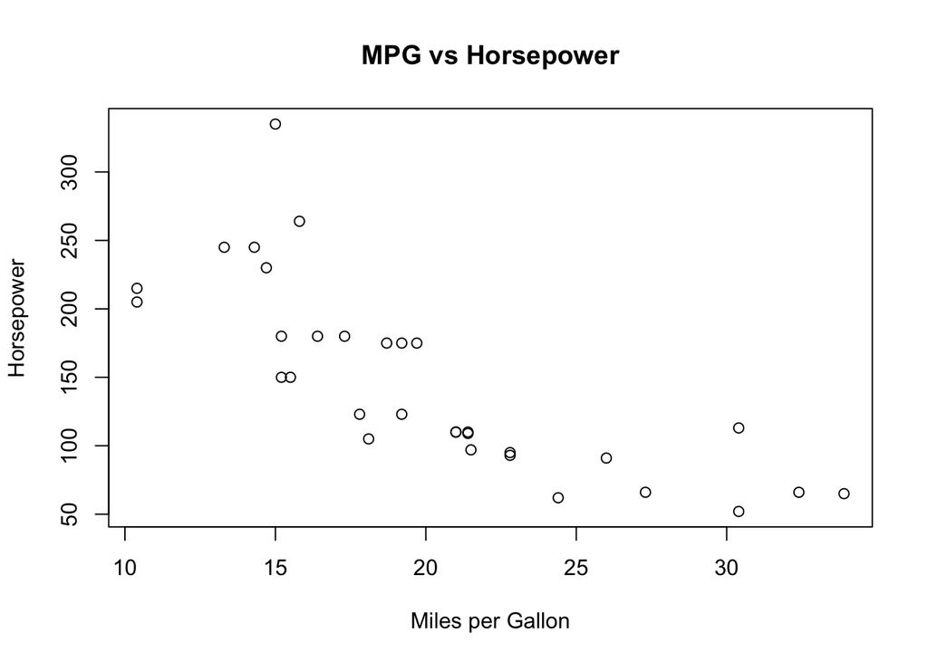

```r
plot(mtcars$mpg, mtcars$hp,
     xlab = "Miles per Gallon",
     ylab = "Horsepower",
     main = "MPG vs Horsepower")
```

### Histogram

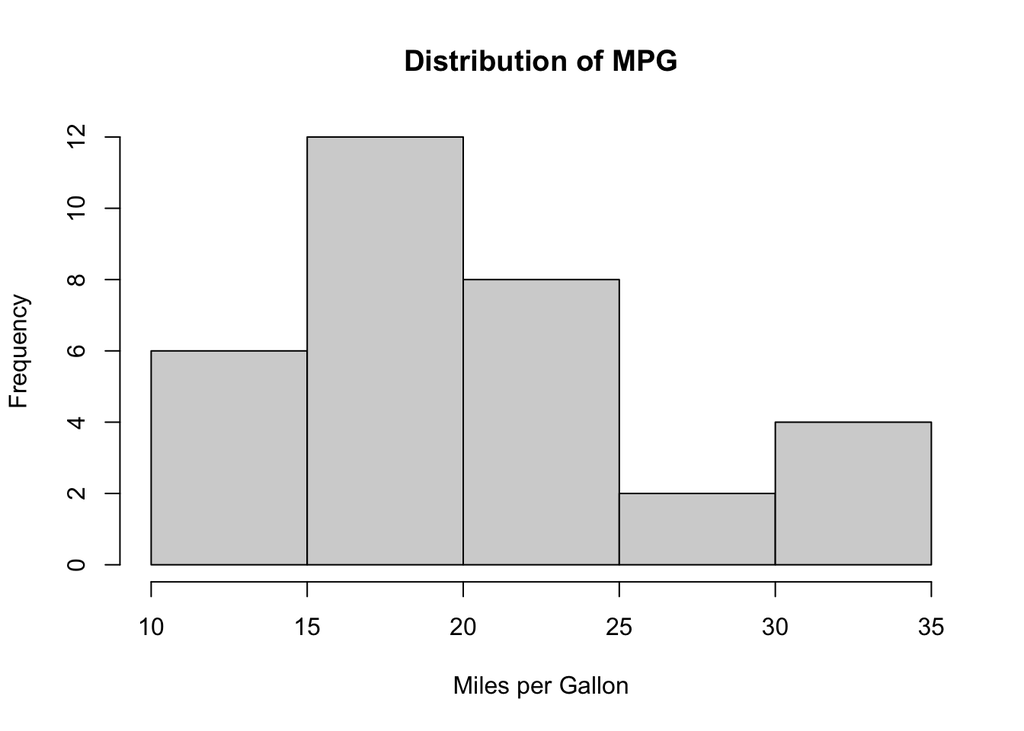

```r
hist(mtcars$mpg,
     main = "Distribution of MPG",
     xlab = "Miles per Gallon")
```

### Exercise 4

Using `mtcars`:

1. Make a scatter plot of `wt` vs `mpg`.
2. Make a histogram of `hp`.

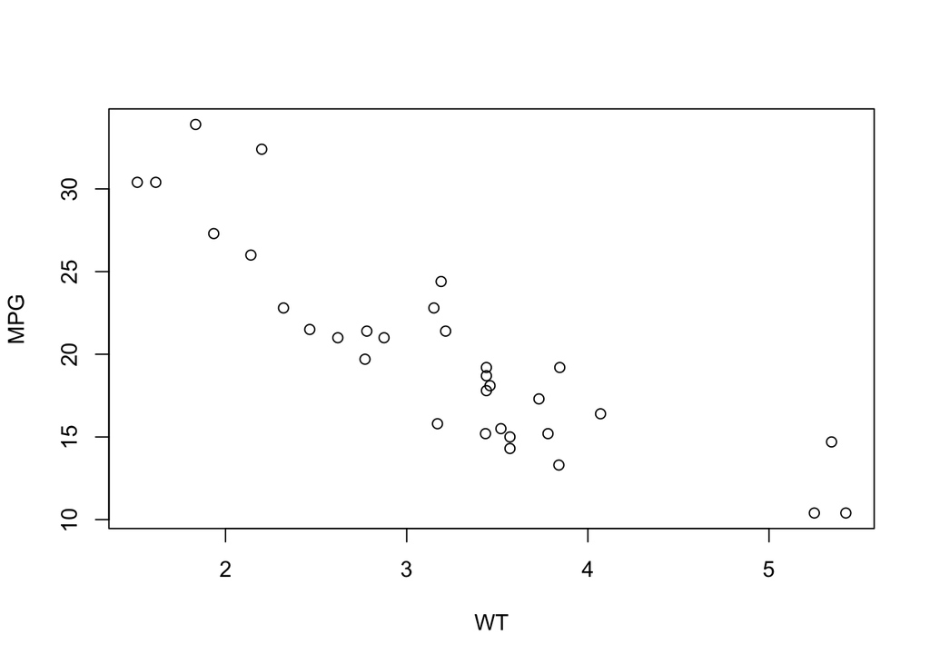

```r
plot(mtcars$wt, mtcars$mpg,
     xlab = 'WT',
     ylab = 'MPG',
     min = 'WT vs MPG'
     )
```

# Part 2: The tidyverse

## What is the tidyverse?

R has **libraries** (also called packages) – collections of extra code that you can use to make R more powerful.

The **tidyverse** is a collection of libraries designed to make data analysis easier and more consistent.  
It includes:

- **dplyr** – easy ways to select, filter, and arrange data
- **ggplot2** – a modern, powerful plotting system
- **readr** – faster and friendlier CSV reading

The tidyverse is popular because it’s **readable**, **consistent**, and **great for data analysis**. We’ll use tidyverse often in this unit.

To install a package, you can use the function `` install.packages(``name_of_the_package``) `` in a code chunk. For example, the following code installs the tidyverse package (we’ve commented it out for now). You only need to install packages once. You can also install packages by clicking on the **Install** button in the bottom right window and searching for your package.

```r
#install.packages("tidyverse")
```

To use in your R session:

```r
library(tidyverse)
```

**Note:** Whenever you want to use a package of code in an R session, you need to load the package with the function `library(name_of_the_package)`

## Reading data

```r
#my_data <- read_csv("myfile.csv")
```

`read_csv()` works like `read.csv()` but is faster and prints data more nicely.

Example with built-in data:

```r
mtcars_tibble <- as_tibble(mtcars)
mtcars_tibble
```

```
# A tibble: 32 × 11
     mpg   cyl  disp    hp  drat    wt  qsec    vs    am  gear  carb
   <dbl> <dbl> <dbl> <dbl> <dbl> <dbl> <dbl> <dbl> <dbl> <dbl> <dbl>
 1  21       6  160    110  3.9   2.62  16.5     0     1     4     4
 2  21       6  160    110  3.9   2.88  17.0     0     1     4     4
 3  22.8     4  108     93  3.85  2.32  18.6     1     1     4     1
 4  21.4     6  258    110  3.08  3.22  19.4     1     0     3     1
 5  18.7     8  360    175  3.15  3.44  17.0     0     0     3     2
 6  18.1     6  225    105  2.76  3.46  20.2     1     0     3     1
 7  14.3     8  360    245  3.21  3.57  15.8     0     0     3     4
 8  24.4     4  147.    62  3.69  3.19  20       1     0     4     2
 9  22.8     4  141.    95  3.92  3.15  22.9     1     0     4     2
10  19.2     6  168.   123  3.92  3.44  18.3     1     0     4     4
# ℹ 22 more rows
```

A **tibble** is a modern data frame with a cleaner print style.

## What is a function?

A function is like a **machine**: you give it inputs, it does something, and gives you an output.  
Example:

```r
sum(1, 2, 3)
```

```
[1] 6
```

Here: - `sum` is the function name. - `(1, 2, 3)` are the inputs.

## The pipe `%>%`

The pipe operator `%>%` passes the result of one function to the next.  
It’s like saying: “Take this, then do that”. It’s very helpful to use pipes when you are doing multiple things to a dataset. Pipes make each step easy to read and debug.

Example:

```r
mtcars_tibble %>%
  select(mpg, hp)
```

```
# A tibble: 32 × 2
     mpg    hp
   <dbl> <dbl>
 1  21     110
 2  21     110
 3  22.8    93
 4  21.4   110
 5  18.7   175
 6  18.1   105
 7  14.3   245
 8  24.4    62
 9  22.8    95
10  19.2   123
# ℹ 22 more rows
```

This means: “Start with `mtcars_tibble`, then select the `mpg` and `hp` columns”.

**Note:** You cannot start a line of code with a pipe `%>%`, this gives an error.

## Selecting multiple columns

In the **tidyverse**, you can select multiple columns by passing more than one column name to `select()`.

```r
mtcars_tibble %>% select(mpg, hp)
```

```
# A tibble: 32 × 2
     mpg    hp
   <dbl> <dbl>
 1  21     110
 2  21     110
 3  22.8    93
 4  21.4   110
 5  18.7   175
 6  18.1   105
 7  14.3   245
 8  24.4    62
 9  22.8    95
10  19.2   123
# ℹ 22 more rows
```

- This keeps just the `mpg` and `hp` columns.

### Selecting a range of columns

```r
mtcars_tibble %>% select(mpg:hp)
```

```
# A tibble: 32 × 4
     mpg   cyl  disp    hp
   <dbl> <dbl> <dbl> <dbl>
 1  21       6  160    110
 2  21       6  160    110
 3  22.8     4  108     93
 4  21.4     6  258    110
 5  18.7     8  360    175
 6  18.1     6  225    105
 7  14.3     8  360    245
 8  24.4     4  147.    62
 9  22.8     4  141.    95
10  19.2     6  168.   123
# ℹ 22 more rows
```

### Saving selected columns into a new tibble or data frame

Sometimes you don’t just want to select columns to look at them — you also want to **save** the result into a new object for later use.

You can do this with the assignment arrow `<-` just like when creating variables.

Example:

```r
# Take the mtcars_tibble
# Select only mpg and hp columns
# Save the result into a new tibble called cars_selected

cars_selected <- mtcars_tibble %>%
  select(mpg, hp)
```

Here’s what’s happening line-by-line:

1. `cars_selected <-` → Create a new tibble called `cars_selected` and store the result here.
2. `mtcars_tibble` → The starting dataset.
3. `%>%` → The **pipe**, which passes the result of one step to the next step.
4. `select(mpg, hp)` → Keep only the `mpg` and `hp` columns.

Now, if we check `cars_selected`:

```r
cars_selected
```

```
# A tibble: 32 × 2
     mpg    hp
   <dbl> <dbl>
 1  21     110
 2  21     110
 3  22.8    93
 4  21.4   110
 5  18.7   175
 6  18.1   105
 7  14.3   245
 8  24.4    62
 9  22.8    95
10  19.2   123
# ℹ 22 more rows
```

It will show a tibble with just those two columns.

### Why is this useful?

- Keeps your original dataset unchanged.
- Creates a smaller dataset with just the variables you need for a particular analysis.
- Makes code easier to read and maintain.

### Exercise 5

1. From `mtcars_tibble`, select the `wt`, `qsec`, and `gear` columns.
2. Save the result into a new tibble called `cars_subset`.
3. Print `cars_subset` to check your result.

```r
cars_subset <- mtcars_tibble %>%
  select(wt,qsec,gear)
print(cars_subset)
```

```
# A tibble: 32 × 3
      wt  qsec  gear
   <dbl> <dbl> <dbl>
 1  2.62  16.5     4
 2  2.88  17.0     4
 3  2.32  18.6     4
 4  3.22  19.4     3
 5  3.44  17.0     3
 6  3.46  20.2     3
 7  3.57  15.8     3
 8  3.19  20       4
 9  3.15  22.9     4
10  3.44  18.3     4
# ℹ 22 more rows
```

## Selecting rows

```r
mtcars_tibble %>% slice(1:5)
```

```
# A tibble: 5 × 11
    mpg   cyl  disp    hp  drat    wt  qsec    vs    am  gear  carb
  <dbl> <dbl> <dbl> <dbl> <dbl> <dbl> <dbl> <dbl> <dbl> <dbl> <dbl>
1  21       6   160   110  3.9   2.62  16.5     0     1     4     4
2  21       6   160   110  3.9   2.88  17.0     0     1     4     4
3  22.8     4   108    93  3.85  2.32  18.6     1     1     4     1
4  21.4     6   258   110  3.08  3.22  19.4     1     0     3     1
5  18.7     8   360   175  3.15  3.44  17.0     0     0     3     2
```

- `slice()` chooses rows by position.

## Filtering rows

```r
mtcars_tibble %>% filter(mpg > 20)
```

```
# A tibble: 14 × 11
     mpg   cyl  disp    hp  drat    wt  qsec    vs    am  gear  carb
   <dbl> <dbl> <dbl> <dbl> <dbl> <dbl> <dbl> <dbl> <dbl> <dbl> <dbl>
 1  21       6 160     110  3.9   2.62  16.5     0     1     4     4
 2  21       6 160     110  3.9   2.88  17.0     0     1     4     4
 3  22.8     4 108      93  3.85  2.32  18.6     1     1     4     1
 4  21.4     6 258     110  3.08  3.22  19.4     1     0     3     1
 5  24.4     4 147.     62  3.69  3.19  20       1     0     4     2
 6  22.8     4 141.     95  3.92  3.15  22.9     1     0     4     2
 7  32.4     4  78.7    66  4.08  2.2   19.5     1     1     4     1
 8  30.4     4  75.7    52  4.93  1.62  18.5     1     1     4     2
 9  33.9     4  71.1    65  4.22  1.84  19.9     1     1     4     1
10  21.5     4 120.     97  3.7   2.46  20.0     1     0     3     1
11  27.3     4  79      66  4.08  1.94  18.9     1     1     4     1
12  26       4 120.     91  4.43  2.14  16.7     0     1     5     2
13  30.4     4  95.1   113  3.77  1.51  16.9     1     1     5     2
14  21.4     4 121     109  4.11  2.78  18.6     1     1     4     2
```

- `filter()` chooses rows based on a condition.

### Exercise 6

Using `mtcars_tibble`:

1. Select only `mpg` and `hp`.
2. Show only rows with `mpg > 25` or `hp > 200`.
3. Show first 5 rows of the result.
4. Save the last selection in a variable named `first_five`

```r
first_five <- mtcars_tibble %>%
  select(mpg, hp) %>%
  filter(mpg > 25 | hp > 200) %>%
  slice(1:5)


print(first_five)
```

```
# A tibble: 5 × 2
    mpg    hp
  <dbl> <dbl>
1  14.3   245
2  10.4   205
3  10.4   215
4  14.7   230
5  32.4    66
```

## Making plots with ggplot2

Making a plot with **ggplot2** follows a pattern:

```r
ggplot(data, aes(x = something, y = something_else)) +
  geom_point()
```

- `ggplot()` starts the plot and sets the data.
- `aes()` tells ggplot which variables go on the x and y axes.
- `geom_point()` adds the points.

Example:

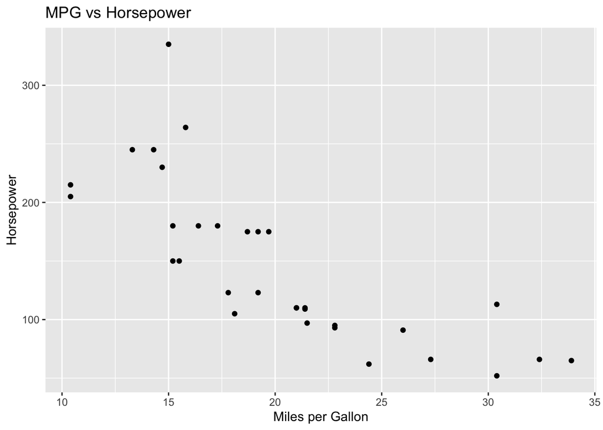

```r
mtcars_tibble %>%
  ggplot(aes(x = mpg, y = hp)) +
  geom_point() +
  labs(title = "MPG vs Horsepower",
       x = "Miles per Gallon",
       y = "Horsepower")
```

Histogram example:

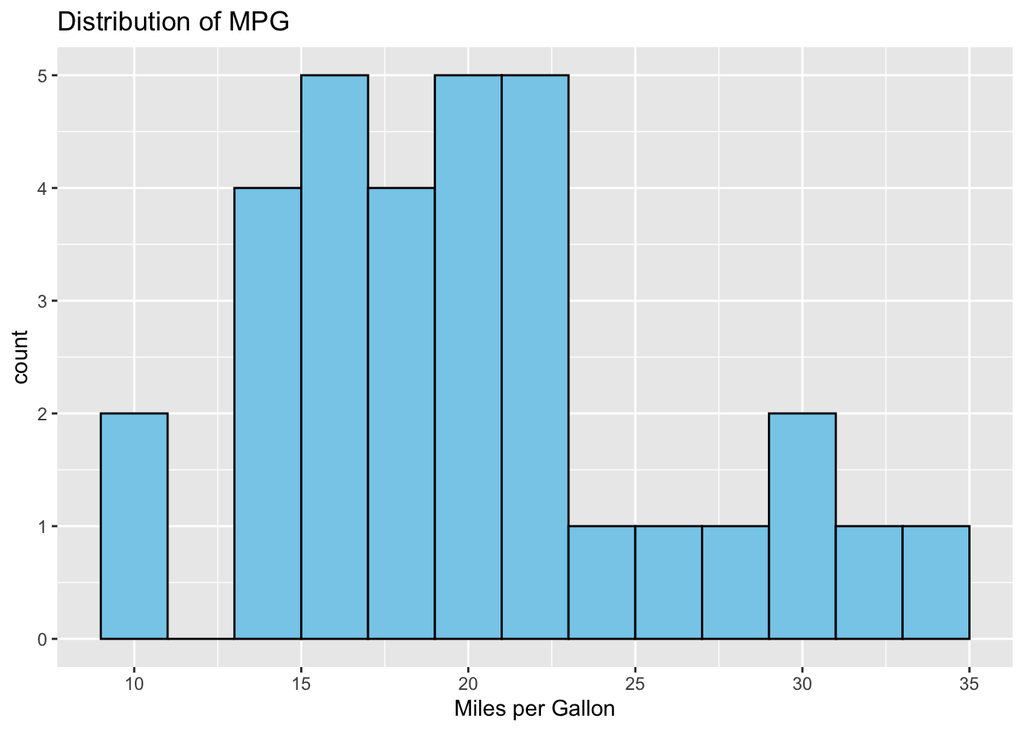

```r
mtcars_tibble %>%
  ggplot(aes(x = mpg)) +
  geom_histogram(binwidth = 2, fill = "skyblue", color = "black") +
  labs(title = "Distribution of MPG",
       x = "Miles per Gallon")
```

### Exercise 5

Using `mtcars_tibble`:

1. Make a scatter plot of `wt` vs `mpg`.
2. Make a histogram of `hp`.

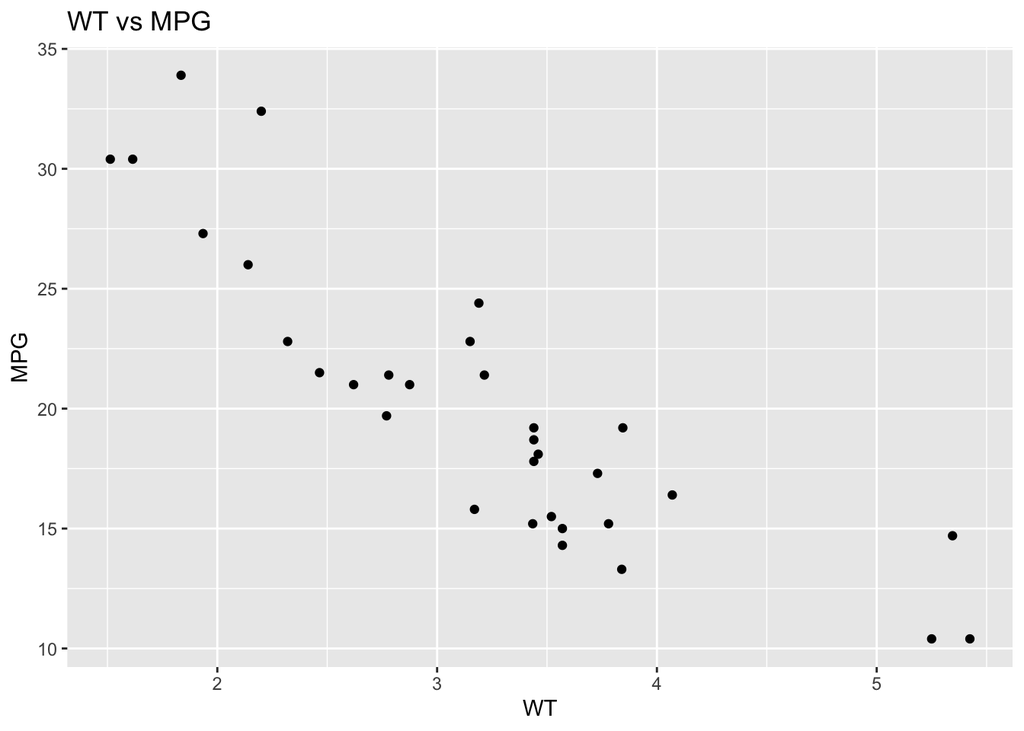

```r
mtcars_tibble %>%
  ggplot(aes(x = wt, y = mpg)) +
  geom_point() +
  labs(title = "WT vs MPG",
       x = "WT",
       y = "MPG")
```

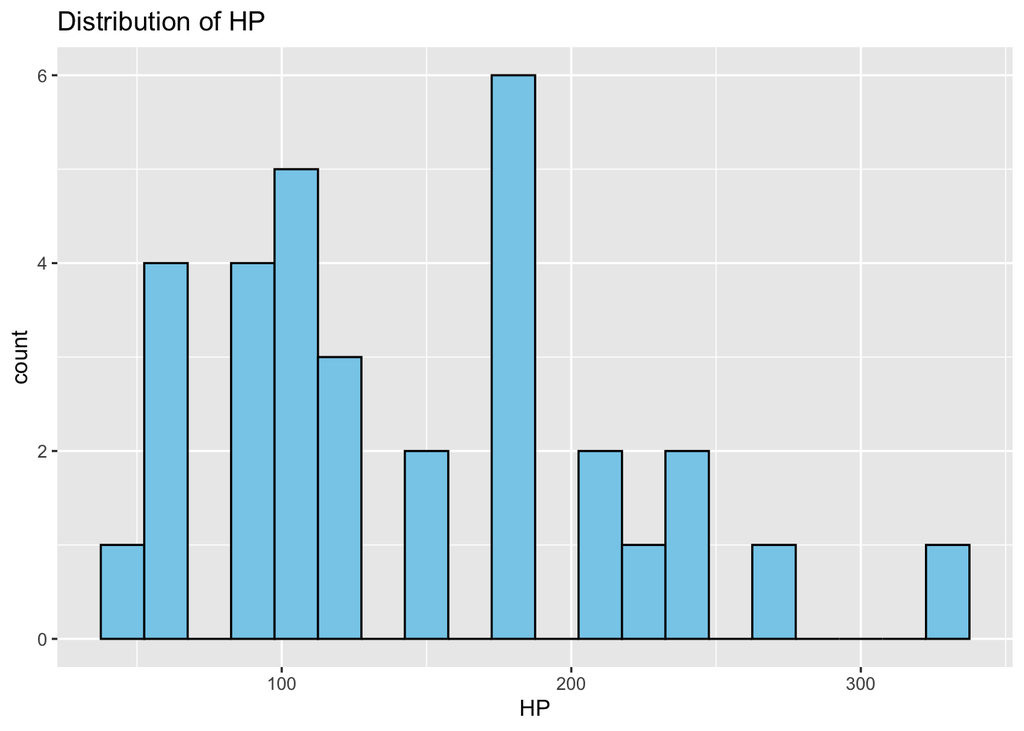

```r
mtcars_tibble %>%
  ggplot(aes(x = hp)) +
  geom_histogram(binwidth = 15, fill = "skyblue", color = "black") +
  labs(title = "Distribution of HP",
       x = "HP")
```